# explore_data

String Lengths

| Mean | 16.0 |
| --- | --- |
| Minimum | 9.0 |
| Maximum | 37.0 |

Histogram

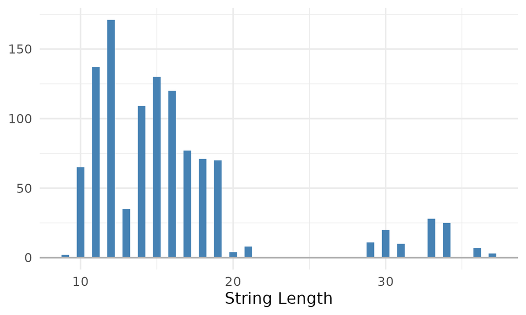

Genus  
`character`

| Distinct | 253 |
| --- | --- |
| `NA`s | 410 |
| `Inf`/`-Inf` | 0 |

**Common Values**

| Value | Count | Frequency |
| --- | --- | --- |
| `NA` | 410 | 28.9% |
| Coniochaeta | 38 | 2.7% |
| Penicillium | 31 | 2.2% |
| Neocucurbitaria | 29 | 2.0% |
| Orbilia | 22 | 1.5% |
| Scytalidium | 22 | 1.5% |
| Eutypa | 20 | 1.4% |
| Scheffersomyces | 20 | 1.4% |
| Exophiala | 19 | 1.3% |
| **Other Values** (790) | 790 | 55.6% |

**String Lengths**

String Lengths

| Mean | 10.8 |
| --- | --- |
| Minimum | 5.0 |
| Maximum | 19.0 |

Histogram

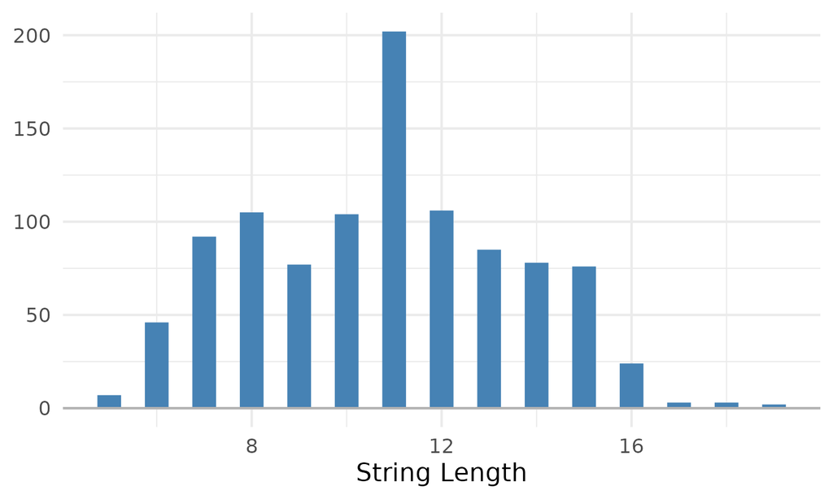

Species  
`character`

| Distinct | 264 |
| --- | --- |
| `NA`s | 769 |
| `Inf`/`-Inf` | 0 |

**Common Values**

| Value | Count | Frequency |
| --- | --- | --- |
| `NA` | 769 | 54.2% |
| adglutinata | 15 | 1.1% |
| spinosa | 15 | 1.1% |
| brevicompactum | 14 | 1.0% |
| stenosporus | 14 | 1.0% |
| lignicola | 13 | 0.9% |
| ostrea | 13 | 0.9% |
| lignosus | 11 | 0.8% |
| raduloides | 11 | 0.8% |
| **Other Values** (535) | 535 | 37.7% |

**String Lengths**

String Lengths

| Mean | 9.4 |
| --- | --- |
| Minimum | 4.0 |
| Maximum | 20.0 |

Histogram

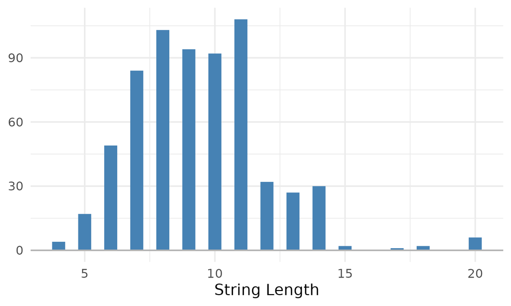

Trophic.Mode  
`character`

| Distinct | 8 |
| --- | --- |
| `NA`s | 0 |
| `Inf`/`-Inf` | 0 |

**Common Values**

| Value | Count | Frequency |
| --- | --- | --- |
| Saprotroph | 531 | 37.4% |
| - | 358 | 25.2% |
| Symbiotroph | 146 | 10.3% |
| Pathotroph-Saprotroph | 137 | 9.6% |
| Pathotroph-Saprotroph-Symbiotroph | 104 | 7.3% |
| Pathotroph | 82 | 5.8% |
| Saprotroph-Symbiotroph | 47 | 3.3% |
| Pathotroph-Symbiotroph | 15 | 1.1% |
| **Other Values** (0) | 0 | 0.0% |

**String Lengths**

String Lengths

| Mean | 11.1 |
| --- | --- |
| Minimum | 1.0 |
| Maximum | 33.0 |

Histogram

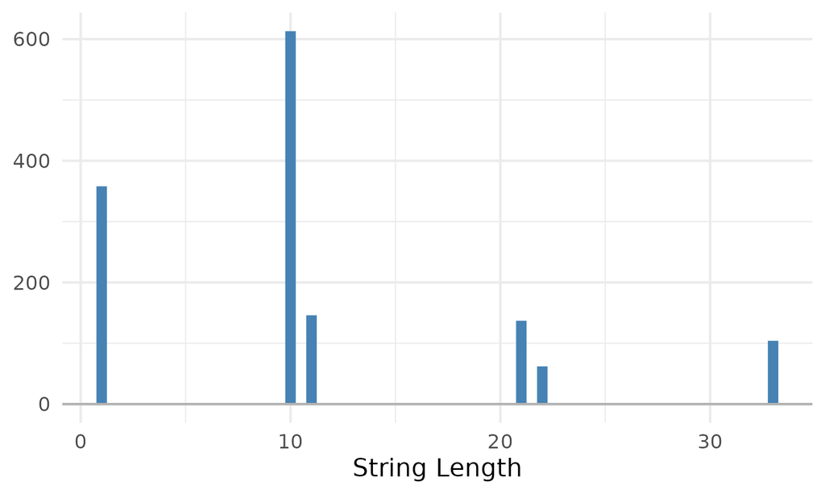

Guild  
`character`

| Distinct | 63 |
| --- | --- |
| `NA`s | 0 |
| `Inf`/`-Inf` | 0 |

**Common Values**

| Value | Count | Frequency |
| --- | --- | --- |
| - | 358 | 25.2% |
| Undefined Saprotroph | 351 | 24.7% |
| Wood Saprotroph | 114 | 8.0% |
| Lichenized | 97 | 6.8% |
| Plant Pathogen | 62 | 4.4% |
| Plant Pathogen-Wood Saprotroph | 39 | 2.7% |
| Animal Pathogen-Dung Saprotroph-Endophyte-Lichen Parasite-Plant Pathogen-Undefined Saprotroph | 38 | 2.7% |
| Undefined Saprotroph-Wood Saprotroph | 31 | 2.2% |
| Fungal Parasite-Undefined Saprotroph | 28 | 2.0% |
| **Other Values** (275) | 275 | 19.4% |

**String Lengths**

String Lengths

| Mean | 20.6 |
| --- | --- |
| Minimum | 1.0 |
| Maximum | 106.0 |

Histogram

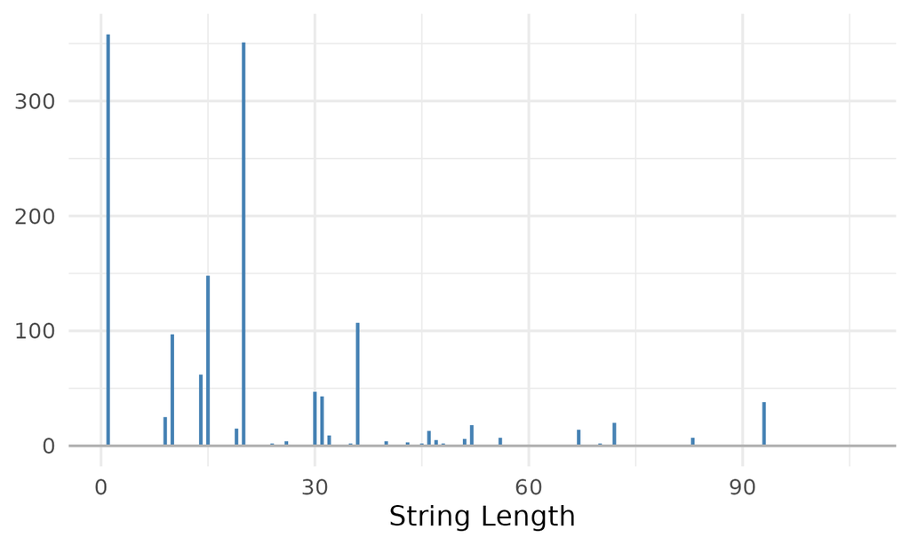

Trait  
`character`

| Distinct | 7 |
| --- | --- |
| `NA`s | 0 |
| `Inf`/`-Inf` | 0 |

**Common Values**

| Value | Count | Frequency |
| --- | --- | --- |
| NULL | 840 | 59.2% |
| - | 358 | 25.2% |
| White Rot | 111 | 7.8% |
| Soft Rot | 76 | 5.4% |
| Brown Rot | 27 | 1.9% |
| Brown Rot-White Rot | 6 | 0.4% |
| Microfungus | 2 | 0.1% |
| **Other Values** (0) | 0 | 0.0% |

**String Lengths**

String Lengths

| Mean | 4.0 |
| --- | --- |
| Minimum | 1.0 |
| Maximum | 19.0 |

Histogram

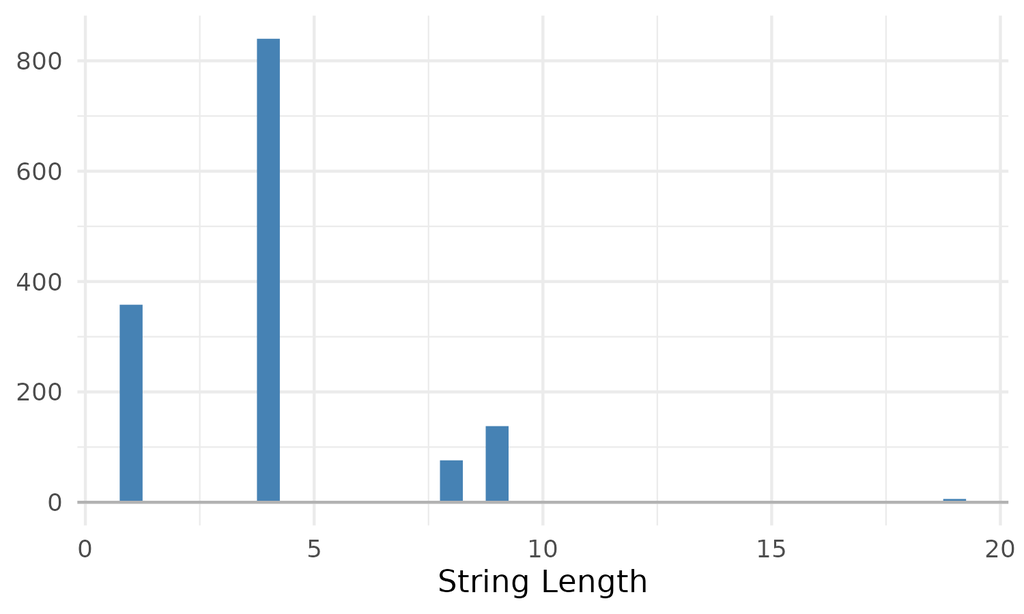

Confidence.Ranking  
`character`

| Distinct | 4 |
| --- | --- |
| `NA`s | 0 |
| `Inf`/`-Inf` | 0 |

**Common Values**

| Value | Count | Frequency |
| --- | --- | --- |
| Probable | 653 | 46.0% |
| - | 358 | 25.2% |
| Possible | 233 | 16.4% |
| Highly Probable | 176 | 12.4% |
| **Other Values** (0) | 0 | 0.0% |

**String Lengths**

String Lengths

| Mean | 7.1 |
| --- | --- |
| Minimum | 1.0 |
| Maximum | 15.0 |

Histogram

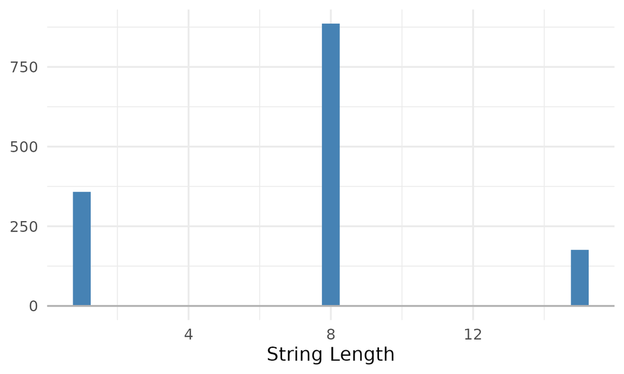

Genus_species  
`character`

| Distinct | 374 |
| --- | --- |
| `NA`s | 0 |
| `Inf`/`-Inf` | 0 |

**Common Values**

| Value | Count | Frequency |
| --- | --- | --- |
| NA_NA | 410 | 28.9% |
| Coniochaeta_NA | 36 | 2.5% |
| Neocucurbitaria_NA | 29 | 2.0% |
| Lentomitella_NA | 16 | 1.1% |
| Penicillium_NA | 16 | 1.1% |
| Eutypa_spinosa | 15 | 1.1% |
| Hyperphyscia_adglutinata | 15 | 1.1% |
| Dacrymyces_stenosporus | 14 | 1.0% |
| Penicillium_brevicompactum | 14 | 1.0% |
| **Other Values** (842) | 842 | 59.3% |

**String Lengths**

String Lengths

| Mean | 14.6 |
| --- | --- |
| Minimum | 5.0 |
| Maximum | 33.0 |

Histogram

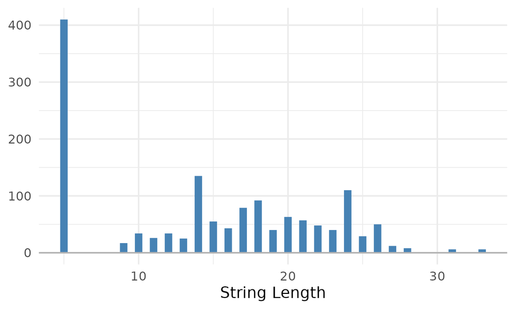

## Sample

|  | Domain | Phylum | Class | Order | Family | Genus | Species | Trophic.Mode | Guild | Trait | Confidence.Ranking | Genus_species |
| --- | --- | --- | --- | --- | --- | --- | --- | --- | --- | --- | --- | --- |
| 1 | Fungi | Ascomycota | Sordariomycetes | Xylariales | Diatrypaceae | Eutypa | spinosa | Pathotroph | Plant Pathogen | NULL | Probable | Eutypa_spinosa |
| 2 | Fungi | Ascomycota | Sordariomycetes | Xylariales | Xylariaceae | Xylaria | `NA` | Saprotroph-Symbiotroph | Endophyte-Undefined Saprotroph-Wood Saprotroph | Soft Rot | Probable | Xylaria_NA |
| 3 | Fungi | Basidiomycota | Agaricomycetes | Russulales | Stereaceae | `NA` | `NA` | Saprotroph | Wood Saprotroph-Undefined Saprotroph | NULL | Probable | NA_NA |
| 4 | Fungi | Basidiomycota | Agaricomycetes | Russulales | Stereaceae | Stereum | ostrea | Saprotroph | Undefined Saprotroph | White Rot | Probable | Stereum_ostrea |
| 5 | Fungi | Ascomycota | Sordariomycetes | `NA` | `NA` | `NA` | `NA` | - | - | - | - | NA_NA |
| 6..1415 |  |  |  |  |  |  |  |  |  |  |  |  |
| 1416 | Fungi | Mucoromycota | Mucoromycetes | Mucorales | Cunninghamellaceae | Absidia | glauca | Saprotroph | Undefined Saprotroph | NULL | Possible | Absidia_glauca |
| 1417 | Fungi | Basidiomycota | Agaricostilbomycetes | Agaricostilbales | `NA` | `NA` | `NA` | - | - | - | - | NA_NA |
| 1418 | Fungi | Rozellomycota | Rozellomycotina_cls_Incertae_sedis | GS05 | `NA` | `NA` | `NA` | - | - | - | - | NA_NA |
| 1419 | Fungi | Ascomycota | Pezizomycotina_cls_Incertae_sedis | Pezizomycotina_ord_Incertae_sedis | Pezizomycotina_fam_Incertae_sedis | Ciliophora | `NA` | - | - | - | - | Ciliophora_NA |
| 1420 | Fungi | Ascomycota | Saccharomycetes | Saccharomycetales | Pichiaceae | Pichia | eremophila | Saprotroph-Symbiotroph | Animal Endosymbiont-Undefined Saprotroph | NULL | Highly Probable | Pichia_eremophila |

## Missing Values

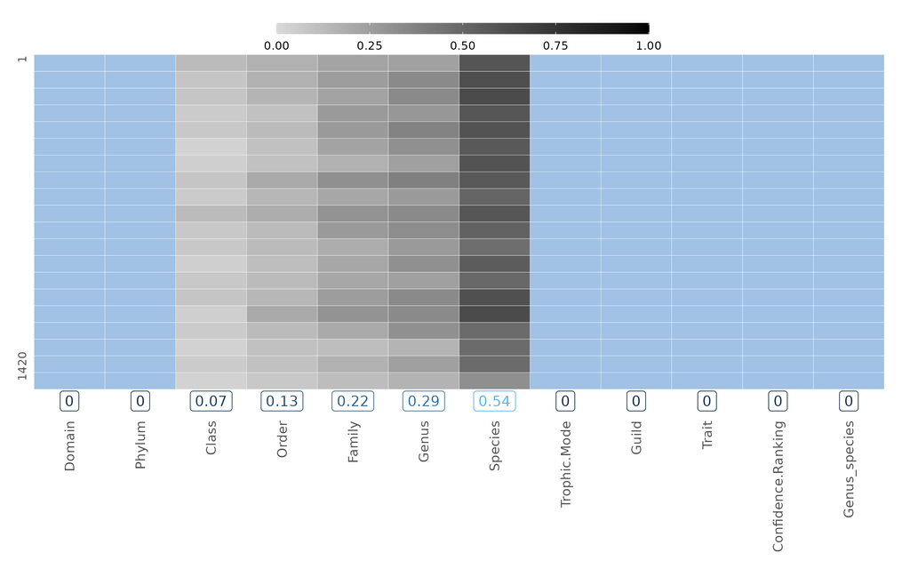

```r
pointblank::create_informant(
  tbl = tax_tab,
  tbl_name = "Taxonomic table",
  label = "data_fungi"
)
```

Pointblank Information

data_fungi tibble Taxonomic tableRows 1,420 Columns 12

| Columns |
| --- |
| `Domain` `character` |
| `Phylum` `character` |
| `Class` `character` |
| `Order` `character` |
| `Family` `character` |
| `Genus` `character` |
| `Species` `character` |
| `Trophic.Mode` `character` |
| `Guild` `character` |
| `Trait` `character` |
| `Confidence.Ranking` `character` |
| `Genus_species` `character` |

2024-02-13 13:06:47 UTC < 1 s 2024-02-13 13:06:47 UTC

```r
gtExtras::gt_plt_summary(tax_tab)
```

tax_tab

1420 rows x 12 cols

Column

Plot Overview

Missing

Mean

Median

SD

**Domain**

Fungi

0.0%

—

—

—

**Phylum**

Ascomycota, Basidiomycota, Rozellomycota, Mucoromycota, Monoblepharomycota and Mortierellomycota

0.0%

—

—

—

**Class**

Sordariomycetes, Agaricomycetes, Dothideomycetes, Leotiomycetes, Eurotiomycetes, Lecanoromycetes, Tremellomycetes, Saccharomycetes, Orbiliomycetes, Dacrymycetes, Microbotryomycetes, Xylonomycetes, Atractiellomycetes, Agaricostilbomycetes, Arthoniomycetes, Cystobasidiomycetes, Pezizomycotina_cls_Incertae_sedis, Pezizomycetes, Umbelopsidomycetes, Malasseziomycetes, Mortierellomycetes, Mucoromycetes, Rozellomycotina_cls_Incertae_sedis, Sanchytriomycetes and Taphrinomycetes

[figure not shown]

6.5%

—

—

—

**Order**

Pleosporales, Helotiales, Chaetothyriales, Xylariales, Capnodiales, Russulales, Agaricales, Saccharomycetales, Hypocreales, Coniochaetales, Lecanorales, Eurotiales, Tremellales, Auriculariales, Hymenochaetales, Orbiliales, Pleurotheciales, Polyporales, Caliciales, Chaetosphaeriales, Dacrymycetales, Sebacinales, Pertusariales, Sordariomycetes_ord_Incertae_sedis, Cantharellales, Sordariales, Togniniales, Microascales, Hysteriales, Sclerococcales, Candelariales, Ostropales, Symbiotaphrinales, Atractiellales, Microbotryomycetes_ord_Incertae_sedis, Trapeliales, Agaricostilbales, Botryosphaeriales, Tubeufiales, Cystofilobasidiales, Filobasidiales, Pezizomycotina_ord_Incertae_sedis, Tremellodendropsidales, Arthoniales, Corticiales, Cystobasidiomycetes_ord_Incertae_sedis, Glomerellales, Pezizales, Thelebolales, Trechisporales, Xenospadicoidales, Annulatascales, Calosphaeriales, Diaporthales, Dothideales, Lichenostigmatales, Myriangiales, Phaeomoniellales, Umbelopsidales, Dothideomycetes_ord_Incertae_sedis, GS05, Lecanoromycetes_ord_Incertae_sedis, Malasseziales, Mortierellales, Mucorales, Phallales, Pisorisporiales, Sanchytriales, Taphrinales, Teloschistales, Thelephorales, Trichosporonales and Venturiales

[figure not shown]

13.3%

—

—

—

**Family**

Herpotrichiellaceae, Coniochaetaceae, Stereaceae, Aspergillaceae, Cucurbitariaceae, Helotiaceae, Pleurotheciaceae, Orbiliaceae, Xylariaceae, Lecanoraceae, Chaetosphaeriaceae, Dacrymycetaceae, Debaryomycetaceae, Diatrypaceae, Physciaceae, Sordariomycetes_fam_Incertae_sedis, Pertusariaceae, Cladosporiaceae, Tricholomataceae, Hypocreales_fam_Incertae_sedis, Cantharellales_fam_Incertae_sedis, Hyaloscyphaceae, Amorosiaceae, Exidiaceae, Sebacinaceae, Hymenochaetaceae, Schizoporaceae, Polyporaceae, Myxotrichaceae, Teratosphaeriaceae, Togniniaceae, Hypocreaceae, Hyaloriaceae, Vibrisseaceae, Hysteriaceae, Lophiotremataceae, Pleosporales_fam_Incertae_sedis, Trichomonascaceae, Candelariaceae, Helminthosphaeriaceae, Helotiales_fam_Incertae_sedis, Lophiostomataceae, Mycosphaerellaceae, Phaeosphaeriaceae, Saccharomycetales_fam_Incertae_sedis, Symbiotaphrinaceae, Atractiellales_fam_Incertae_sedis, Entolomataceae, Graphiaceae, Nectriaceae, Parmeliaceae, Phlyctidaceae, Pleomonodictydaceae, Stictidaceae, Tremellaceae, Bulleribasidiaceae, Dactylosporaceae, Peniophoraceae, Tubeufiaceae, Auriculariaceae, Botryosphaeriaceae, Cephalothecaceae, Didymellaceae, Hericiaceae, Hyphodermataceae, Lasiosphaeriaceae, Lentitheciaceae, Lyophyllaceae, Mrakiaceae, Occultibambusaceae, Pezizomycotina_fam_Incertae_sedis, Pleosporaceae, Chionosphaeraceae, Chrysozymaceae, Corticiaceae, Cyphellophoraceae, Hymenochaetales_fam_Incertae_sedis, Leotiaceae, Leptosphaeriaceae, Microbotryomycetes_fam_Incertae_sedis, Omphalotaceae, Phaeotremellaceae, Pseudeurotiaceae, Roccellaceae, Steccherinaceae, Xenospadicoidaceae, Agaricales_fam_Incertae_sedis, Annulatascaceae, Bionectriaceae, Botryobasidiaceae, Caliciaceae, Calosphaeriaceae, Capnodiales_fam_Incertae_sedis, Carcinomycetaceae, Cerrenaceae, Dermateaceae, Didymosphaeriaceae, Filobasidiaceae, Gondwanamycetaceae, Meruliaceae, Ochrolechiaceae, Phaeococcomycetaceae, Phaeomoniellaceae, Piskurozymaceae, Pluteaceae, Psathyrellaceae, Ramalinaceae, Serendipitaceae, Sirobasidiaceae, Trechisporales_fam_Incertae_sedis, Trichomeriaceae, Tympanidaceae, Umbelopsidaceae, Valsaceae, Amanitaceae, Aporpiaceae, Ascobolaceae, Aureobasidiaceae, Biatriosporaceae, Buckleyzymaceae, Bulleraceae, Catillariaceae, Chaetomiaceae, Clavariaceae, Coniothyriaceae, Cortinariaceae, Cunninghamellaceae, Dothideomycetes_fam_Incertae_sedis, Dothioraceae, Glomerellaceae, Hydnodontaceae, Irpicaceae, Kondoaceae, Massarinaceae, Microascales_fam_Incertae_sedis, Micropeltidaceae, Microsporomycetaceae, Mortierellaceae, Myriangiaceae, Myriangiales_fam_Incertae_sedis, Neodevriesiaceae, Pezizaceae, Phallaceae, Phanerochaetaceae, Pichiaceae, Pisorisporiaceae, Plectosphaerellaceae, Pleurotaceae, Porinaceae, Pterulaceae, Pyronemataceae, Rhynchogastremataceae, Russulales_fam_Incertae_sedis, Saccharomycodaceae, Sanchytriaceae, Sordariales_fam_Incertae_sedis, Syzygosporaceae, Taphrinaceae, Teloschistaceae, Thelephoraceae, Trichosporonaceae, Venturiaceae and Xylariales_fam_Incertae_sedis

[figure not shown]

22.3%

—

—

—

**Genus**

Coniochaeta, Penicillium, Neocucurbitaria, Orbilia, Scytalidium, Eutypa, Scheffersomyces, Exophiala, Pertusaria, Phaeoisaria, Cladosporium, Lecanora, Stereum, Lentomitella, Angustimassarina, Hyperphyscia, Sistotrema, Dacrymyces, Xylaria, Xylodon, Mycena, Phaeoacremonium, Capronia, Rhinocladiella, Zignoella, Calocera, Phialocephala, Trichoderma, Barbatosphaeria, Biscogniauxia, Catenulostroma, Exidia, Inonotus, Lophiotrema, Oidiodendron, Pleurothecium, Basidiodendron, Hysterobrevium, Lecidella, Mycosphaerella, Spadicoides, Symbiotaphrina, Trametes, Calycina, Chaetospermum, Cryptocoryneum, Cryptodiscus, Fomes, Graphium, Helicogloea, Lophiostoma, Melanchlenus, Phlyctis, Pleomonodictys, Stypella, Tremella, Cadophora, Candelariella, Dactylospora, Natantiella, Peniophora, Resupinatus, Auricularia, Brunneofusispora, Chloridium, Ciliophora, Fomitiporella, Hericium, Hyphoderma, Lachnum, Nemania, Ossicaulis, Parmelina, Physcia, Sugiyamaella, Tausonia, Vishniacozyma, Acericola, Alternaria, Aspergillus, Candida, Chaetosphaeria, Clitopilus, Colacogloea, Cryptendoxyla, Cyphellophora, Diddensiella, Entocybe, Hyaloscypha, Omphalotus, Peniophorella, Phaeotremella, Plenodomus, Pseudodiplococcium, Retiarius, Rhamphoria, Schizothecium, Scoliciosporum, Acanthostigma, Arthrocatena, Bactrospora, Bisporella, Botryobasidium, Brachysporium, Candelaria, Carcinomyces, Ceriporiopsis, Cerrena, Chlorociboria, Chondrostereum, Custingophora, Devriesia, Diatrype, Fibulobasidium, Hamamotoa, Jattaea, Knufia, Lasionectria, Leohumicola, Marchandiomyces, Ochrolechia, Paraconiothyrium, Parafenestella, Paraphoma, Phaeococcomyces, Phaeophyscia, Piskurozyma, Pluteus, Pyrenochaeta, Rhopalophora, Scopuloides, Sistotremastrum, Suhomyces, Torrentispora, Umbelopsis, Veronaea, Vexillomyces, Xylomelasma, Absidia, Achroceratosphaeria, Acremonium, Alatospora, Amandinea, Amanita, Amaurodon, Antrodiella, Arachnopeziza, Arthrobotrys, Articulospora, Ascobolus, Aureobasidium, Bacidia, Bannozyma, Bensingtonia, Biatriospora, Blastobotrys, Buckleyzyma, Buellia, Burgoa, Caloplaca, Catillaria, Catinella, Cephalotrichiella, Ceriporia, Ciliciopodium, Clonostachys, Colletotrichum, Collophora, Coniothyrium, Coprinellus, Coprinopsis, Corticium, Cutaneotrichosporon, Cystobasidiopsis, Cytospora, Dactylaria, Daldinia, Debaryomyces, Dendrographa, Dioszegia, Diplodia, Dothiorella, Durella, Elmerina, Endosporium, Everhartia, Filobasidium, Flavoparmelia, Fonsecazyma, Fuscoporia, Gibberella, Gibellulopsis, Gloeohypochnicium, Gorgomyces, Gymnopilus, Hanseniaspora, Helicosporium, Hormonema, Hyalorbilia, Hyphodiscus, Hypoxylon, Kretzschmaria, Kuraishia, Kurtzmanomyces, Lasiosphaeris, Libertasomyces, Massarina, Merismodes, Microcera, Mollisia, Monocillium, Mortierella, Mucronella, Murilentithecium, Mycenella, Myriangium, Myxarium, Myxozyma, Naganishia, Neohendersonia, Peziza, Pezoloma, Phallus, Phanerochaete, Phialemoniopsis, Phialemonium, Phialophora, Phoma, Pichia, Platystomum, Pleurotus, Porina, Porosphaerella, Priceomyces, Protomerulius, Pseudogymnoascus, Punctelia, Rachicladosporium, Radulomyces, Ramalina, Rhodoveronaea, Rhynchogastrema, Sanchytrium, Schwanniomyces, Sphaeropsis, Stemphylium, Strossmayeria, Suttonomyces, Syzygospora, Taphrina, Tintelnotia and Trechispora

[figure not shown]

28.9%

—

—

—

**Species**

adglutinata, spinosa, brevicompactum, stenosporus, lignicola, ostrea, lignosus, raduloides, acerina, leioplaca, oblonga, nummularia, stipitis, buchneri, constrictum, cornea, eyrei, neglecta, pertusa, versicolor, agelaea, austrohemisphaericum, claroflava, condensatum, cynaroidis, descalsii, eumetabolus, fomentarius, glandulosa, semifecundum, glabrata, ligneola, microstomus, obliquus, oblongisporum, pellucida, pullulans, sedimenticola, sparsa, tassiana, album, bina, coralloides, eucalypti, f._elaeochroma, lachnopus, periconioides, poriaeformis, renati, sinensis, stellaris, subgelatinosa, albohyalina, biglobosus, brinkmannii, coronilla, elaeochroma, euonymi, griseum, hirsutum, hobsonii, hybocarpa, hypophloia, ibericum, inflatipes, italica, olearius, olivacea, pilosella, premilcurensis, pyriformis, rickii, santjacobensis, setigerum, tiliacea, victoriae, vrijmoediae, xanthostigma, aeruginascens, aurantiacum, bergeri, boreocaroliniensis, buckii, calembola, cejpii, clavispora, concolor, conicus, cycloclastica, delicatulum, denigrata, disciformis, fimeti, hydnoides, inflorescentiae, intumescens, mackenziei, maritima, melinii, oenanthicola, perpusillum, phaeophora, polyporina, pubera, purpureum, salmonis, subcarpinea, taiwanensis, verruculosus, abramsii, acuminata, acutiseta, albida, aloes, analogum, angulospora, antibiotica, aphanospora, appendiculatus, aprilis, atakaporum, aurantia, aurantiaca, aurella, auricula-judae, barbirostris, basitricha, bialowiezense, blanchettei, boreale, brasiliensis, brevipes, byssophila, candicans, carpini, carporrhizans, caryae, cenisia, chlorococcum, cidri, cinerea, citrina, cladodes, consobrina, cordanophora, crataegi, croatiense, dermatis, deusta, discreta, dispersa, duriaei, eburnea, encephala, eremophila, ergatensis, ericae, erythrostigma, expanda, fasciculata, ferruginosa, flaviporus, fraxinigena, gilvescens, glauca, glycines, grilletii, guilliermondii, guttuliferum, halotolerans, hennebertii, hermanusense, hispida, humilis, hungarica, hymeniophilus, impudicus, inconspicuum, inflatum, isabellina, japonica, kavinii, kickxii, lacerata, lagerheimii, lignatilis, ligni, ligniaria, lignophila, livescens, lloydiae-candidae, lophatheri, macrocarpum, macrospora, mayrhoferi, melibiosi, mesenterica, metachromatica, mexicanus, micaceus, mitrata, molaris, moniliae, myopori, nigrescens, nigroclavata, nigrum, niveocremeum, novakii, obovoideum, obscurella, ocularis, pallescens, parasitica, penetrans, penicillata, piceae, plautus, pluriseptata, polymorphus, potamia, praetermissa, prunicola, pseudofoliacea, pseudoseriata, pulmonarius, punctata, raimundi, recurvatum, reesei, reflexa, rimosissimus, rosae, rosea, roseocremeum, rubefacta, sardiniae, sepiacea, singularis, soredians, sphaerospermum, subpallida, subrudecta, subviridis, tenebricosa, tenebrio, tenue, tephrensis, trachyspora, tumefaciens, umbrinum, vadensis, variabilis, varioseptata, vermifera, versiformis, verzuoliana, vinosa, virgineum, viridis, vitellina, wieringae and yamatoana

[figure not shown]

54.2%

—

—

—

**Trophic.Mode**

Saprotroph, -, Symbiotroph, Pathotroph-Saprotroph, Pathotroph-Saprotroph-Symbiotroph, Pathotroph, Saprotroph-Symbiotroph and Pathotroph-Symbiotroph

0.0%

—

—

—

**Guild**

-, Undefined Saprotroph, Wood Saprotroph, Lichenized, Plant Pathogen, Plant Pathogen-Wood Saprotroph, Animal Pathogen-Dung Saprotroph-Endophyte-Lichen Parasite-Plant Pathogen-Undefined Saprotroph, Undefined Saprotroph-Wood Saprotroph, Fungal Parasite-Undefined Saprotroph, Animal Pathogen-Undefined Saprotroph, Endophyte, Animal Pathogen-Endophyte-Lichen Parasite-Plant Pathogen-Wood Saprotroph, Wood Saprotroph-Undefined Saprotroph, Ectomycorrhizal, Animal Pathogen-Fungal Parasite-Undefined Saprotroph, Ectomycorrhizal-Wood Saprotroph, Fungal Parasite-Wood Saprotroph, Endophyte-Undefined Saprotroph-Wood Saprotroph, Leaf Saprotroph-Plant Pathogen-Undefined Saprotroph-Wood Saprotroph, Plant Saprotroph-Wood Saprotroph, Endophyte-Undefined Saprotroph, Ericoid Mycorrhizal, Animal Endosymbiont, Fungal Parasite-Lichen Parasite, Lichen Parasite, Animal Pathogen-Lichen Parasite-Plant Pathogen-Undefined Saprotroph-Wood Saprotroph, Fungal Parasite-Plant Pathogen-Plant Saprotroph, Animal Pathogen-Plant Pathogen-Undefined Saprotroph, Ectomycorrhizal-Endophyte-Plant Pathogen-Wood Saprotroph, Fungal Parasite, Lichen Parasite-Lichenized, Animal Pathogen-Endophyte-Plant Pathogen-Wood Saprotroph, Dung Saprotroph, Ectomycorrhizal-Undefined Saprotroph, Endophyte-Litter Saprotroph-Wood Saprotroph, Endophyte-Plant Pathogen-Wood Saprotroph, Animal Pathogen, Animal Pathogen-Plant Pathogen-Soil Saprotroph-Undefined Saprotroph, Bryophyte Parasite-Litter Saprotroph-Wood Saprotroph, Dung Saprotroph-Plant Saprotroph-Wood Saprotroph, Endophyte-Plant Pathogen, Endophyte-Plant Pathogen-Undefined Saprotroph, Leaf Saprotroph-Plant Pathogen-Undefined Saprotroph, Plant Pathogen-Plant Saprotroph, Plant Pathogen-Undefined Saprotroph, Animal Endosymbiont-Undefined Saprotroph, Animal Pathogen-Dung Saprotroph-Endophyte-Epiphyte-Plant Saprotroph-Wood Saprotroph, Animal Pathogen-Endophyte-Epiphyte-Plant Pathogen-Undefined Saprotroph, Animal Pathogen-Endophyte-Ericoid Mycorrhizal-Plant Pathogen-Wood Saprotroph, Animal Pathogen-Endophyte-Fungal Parasite-Plant Pathogen-Wood Saprotroph, Animal Pathogen-Soil Saprotroph, Bryophyte Parasite-Ectomycorrhizal-Ericoid Mycorrhizal-Undefined Saprotroph-Wood Saprotroph, Dung Saprotroph-Ectomycorrhizal-Litter Saprotroph-Undefined Saprotroph, Dung Saprotroph-Ectomycorrhizal-Soil Saprotroph-Wood Saprotroph, Dung Saprotroph-Endophyte-Plant Pathogen-Undefined Saprotroph, Dung Saprotroph-Wood Saprotroph, Ectomycorrhizal-Fungal Parasite, Endophyte-Dung Saprotroph-Lichen Parasite-Litter Saprotroph-Plant Pathogen-Soil Saprotroph-Wood Saprotroph, Endophyte-Litter Saprotroph-Soil Saprotroph-Undefined Saprotroph, Endophyte-Wood Saprotroph-Animal Pathogen, Epiphyte-Plant Pathogen-Wood Saprotroph, Litter Saprotroph-Soil Saprotroph-Wood Saprotroph and Soil Saprotroph

[figure not shown]

0.0%

—

—

—

**Trait**

NULL, -, White Rot, Soft Rot, Brown Rot, Brown Rot-White Rot and Microfungus

0.0%

—

—

—

**Confidence.Ranking**

Probable, -, Possible and Highly Probable

0.0%

—

—

—

**Genus_species**

NA_NA, Coniochaeta_NA, Neocucurbitaria_NA, Lentomitella_NA, Penicillium_NA, Eutypa_spinosa, Hyperphyscia_adglutinata, Dacrymyces_stenosporus, Penicillium_brevicompactum, Exophiala_NA, Scytalidium_lignicola, Stereum_ostrea, Xylaria_NA, Scheffersomyces_lignosus, Angustimassarina_acerina, Zignoella_NA, Orbilia_NA, Pertusaria_leioplaca, Phaeoisaria_NA, Phialocephala_oblonga, Xylodon_raduloides, Biscogniauxia_nummularia, Cladosporium_NA, Rhinocladiella_NA, Scheffersomyces_stipitis, Trichoderma_NA, Barbatosphaeria_neglecta, Basidiodendron_eyrei, Calocera_cornea, Catenulostroma_NA, Hysterobrevium_constrictum, Lophiotrema_NA, Mycena_NA, Pertusaria_pertusa, Phaeoacremonium_NA, Symbiotaphrina_buchneri, Trametes_versicolor, Calycina_claroflava, Capronia_NA, Chaetospermum_NA, Cladosporium_austrohemisphaericum, Cryptocoryneum_condensatum, Exidia_glandulosa, Fomes_fomentarius, Graphium_NA, Lophiostoma_cynaroidis, Melanchlenus_eumetabolus, Phlyctis_agelaea, Pleomonodictys_descalsii, Pleurothecium_semifecundum, Cryptodiscus_microstomus, Eutypa_NA, Helicogloea_pellucida, Inonotus_obliquus, Lecanora_glabrata, Mycosphaerella_tassiana, Natantiella_ligneola, Phaeoisaria_sedimenticola, Phaeoisaria_sparsa, Sistotrema_oblongisporum, Brunneofusispora_sinensis, Chloridium_NA, Ciliophora_NA, Fomitiporella_NA, Hericium_coralloides, Lecidella_f._elaeochroma, Mycena_renati, Oidiodendron_periconioides, Ossicaulis_lachnopus, Physcia_stellaris, Resupinatus_poriaeformis, Scytalidium_album, Spadicoides_bina, Stypella_subgelatinosa, Tausonia_pullulans, Acericola_italica, Angustimassarina_premilcurensis, Cadophora_NA, Candida_santjacobensis, Capronia_pilosella, Chaetosphaeria_NA, Clitopilus_hobsonii, Cryptendoxyla_hypophloia, Dactylospora_vrijmoediae, Diddensiella_NA, Entocybe_NA, Hyaloscypha_albohyalina, Hyphoderma_setigerum, Inonotus_rickii, Lachnum_NA, Lecanora_hybocarpa, Lecanora_NA, Lecidella_elaeochroma, Oidiodendron_griseum, Omphalotus_olearius, Orbilia_eucalypti, Orbilia_euonymi, Parmelina_tiliacea, Phaeoacremonium_inflatipes, Plenodomus_biglobosus, Pseudodiplococcium_ibericum, Retiarius_NA, Rhamphoria_pyriformis, Schizothecium_NA, Scytalidium_NA, Sistotrema_brinkmannii, Sistotrema_coronilla, Spadicoides_NA, Stereum_hirsutum, Vishniacozyma_victoriae, Acanthostigma_perpusillum, Alternaria_NA, Angustimassarina_NA, Aspergillus_conicus, Auricularia_NA, Bactrospora_NA, Cadophora_melinii, Calocera_NA, Candelaria_concolor, Carcinomyces_polyporina, Cerrena_NA, Chlorociboria_aeruginascens, Chondrostereum_purpureum, Cladosporium_delicatulum, Colacogloea_cycloclastica, Cyphellophora_olivacea, Diatrype_disciformis, Exidia_NA, Exophiala_bergeri, Exophiala_salmonis, Knufia_NA, Lasionectria_oenanthicola, Lecanora_intumescens, Lecanora_subcarpinea, Leohumicola_NA, Marchandiomyces_buckii, Mycosphaerella_NA, Nemania_maritima, Nemania_NA, Orbilia_cejpii, Orbilia_xanthostigma, Paraconiothyrium_NA, Parafenestella_mackenziei, Paraphoma_fimeti, Peniophora_NA, Peniophorella_pubera, Pertusaria_NA, Phaeophyscia_denigrata, Phaeotremella_NA, Piskurozyma_taiwanensis, Pyrenochaeta_inflorescentiae, Rhinocladiella_phaeophora, Rhopalophora_clavispora, Scopuloides_hydnoides, Scytalidium_aurantiacum, Sistotrema_NA, Sistotrema_raduloides, Sugiyamaella_boreocaroliniensis, Torrentispora_calembola, Tremella_NA, Vexillomyces_verruculosus, Xylodon_NA, Xylomelasma_NA, Absidia_glauca, Achroceratosphaeria_potamia, Acremonium_hennebertii, Alatospora_NA, Alternaria_metachromatica, Amandinea_punctata, Amanita_sepiacea, Amaurodon_viridis, Antrodiella_brasiliensis, Arachnopeziza_NA, Arthrobotrys_cladodes, Arthrocatena_NA, Arthrocatena_tenebrio, Articulospora_NA, Ascobolus_NA, Aspergillus_NA, Aureobasidium_pullulans, Auricularia_auricula-judae, Auricularia_mesenterica, Bacidia_vermifera, Bannozyma_yamatoana, Barbatosphaeria_barbirostris, Bensingtonia_NA, Biatriospora_antibiotica, Bisporella_citrina, Bisporella_subpallida, Blastobotrys_NA, Botryobasidium_candicans, Botryobasidium_NA, Brachysporium_NA, Brachysporium_nigrum, Buckleyzyma_aurantiaca, Buellia_NA, Burgoa_verzuoliana, Caloplaca_obscurella, Candelariella_aurella, Candelariella_NA, Candelariella_reflexa, Candelariella_vitellina, Candelariella_xanthostigma, Capronia_acutiseta, Catenulostroma_hermanusense, Catillaria_nigroclavata, Catinella_olivacea, Cephalotrichiella_penicillata, Ceriporia_lacerata, Ceriporiopsis_consobrina, Ceriporiopsis_gilvescens, Ciliciopodium_brevipes, Cladosporium_halotolerans, Cladosporium_sphaerospermum, Clonostachys_rosea, Colacogloea_NA, Colletotrichum_NA, Collophora_NA, Coniochaeta_ligniaria, Coniochaeta_prunicola, Coniothyrium_glycines, Coprinellus_micaceus, Coprinopsis_NA, Corticium_NA, Cryptodiscus_NA, Custingophora_blanchettei, Custingophora_NA, Cutaneotrichosporon_dermatis, Cyphellophora_pluriseptata, Cystobasidiopsis_lophatheri, Cytospora_fraxinigena, Dactylaria_mitrata, Dactylospora_NA, Dactylospora_parasitica, Daldinia_raimundi, Debaryomyces_NA, Dendrographa_NA, Devriesia_NA, Devriesia_sardiniae, Dioszegia_hungarica, Diplodia_pseudoseriata, Dothiorella_NA, Durella_macrospora, Elmerina_caryae, Endosporium_NA, Everhartia_lignatilis, Exophiala_angulospora, Exophiala_moniliae, Fibulobasidium_inconspicuum, Fibulobasidium_NA, Filobasidium_wieringae, Flavoparmelia_soredians, Fonsecazyma_NA, Fuscoporia_ferruginosa, Gibberella_acuminata, Gibellulopsis_nigrescens, Gloeohypochnicium_analogum, Gorgomyces_NA, Gymnopilus_penetrans, Hamamotoa_lignophila, Hamamotoa_singularis, Hanseniaspora_guilliermondii, Helicogloea_lagerheimii, Helicosporium_NA, Hormonema_NA, Hyalorbilia_erythrostigma, Hyphoderma_roseocremeum, Hyphodiscus_hymeniophilus, Hypoxylon_macrocarpum, Jattaea_aphanospora, Jattaea_discreta, Kretzschmaria_deusta, Kuraishia_cidri, Kurtzmanomyces_NA, Lachnum_virgineum, Lasiosphaeris_hispida, Lecanora_cenisia, Lecanora_dispersa, Libertasomyces_myopori, Lophiotrema_boreale, Massarina_eburnea, Merismodes_fasciculata, Microcera_NA, Mollisia_ligni, Monocillium_tenue, Mortierella_humilis, Mucronella_NA, Murilentithecium_NA, Mycena_abramsii, Mycenella_trachyspora, Myriangium_duriaei, Myxarium_NA, Myxozyma_melibiosi, Naganishia_albida, Neohendersonia_kickxii, Ochrolechia_pallescens, Ochrolechia_subviridis, Oidiodendron_NA, Orbilia_aprilis, Orbilia_tenebricosa, Orbilia_vinosa, Parmelina_carporrhizans, Penicillium_bialowiezense, Peniophora_cinerea, Peniophora_piceae, Peniophora_versiformis, Peniophorella_praetermissa, Pertusaria_rubefacta, Peziza_NA, Pezoloma_ericae, Phaeoacremonium_croatiense, Phaeococcomyces_eucalypti, Phaeococcomyces_mexicanus, Phaeotremella_pseudofoliacea, Phallus_impudicus, Phanerochaete_livescens, Phialemoniopsis_ocularis, Phialemonium_inflatum, Phialophora_expanda, Phoma_aloes, Pichia_eremophila, Platystomum_crataegi, Pleurothecium_obovoideum, Pleurothecium_recurvatum, Pleurotus_pulmonarius, Pluteus_NA, Pluteus_plautus, Porina_byssophila, Porosphaerella_cordanophora, Priceomyces_NA, Protomerulius_NA, Pseudogymnoascus_appendiculatus, Punctelia_subrudecta, Rachicladosporium_NA, Radulomyces_molaris, Ramalina_NA, Resupinatus_kavinii, Rhodoveronaea_varioseptata, Rhynchogastrema_NA, Sanchytrium_NA, Scheffersomyces_ergatensis, Schwanniomyces_polymorphus, Scoliciosporum_chlorococcum, Scoliciosporum_NA, Scoliciosporum_umbrinum, Sistotremastrum_guttuliferum, Sistotremastrum_niveocremeum, Sphaeropsis_tumefaciens, Stemphylium_NA, Stereum_NA, Strossmayeria_basitricha, Stypella_grilletii, Stypella_variabilis, Sugiyamaella_NA, Sugiyamaella_novakii, Suhomyces_atakaporum, Suhomyces_vadensis, Suttonomyces_rosae, Syzygospora_NA, Taphrina_carpini, Tintelnotia_NA, Trechispora_NA, Tremella_aurantia, Tremella_encephala, Tremella_lloydiae-candidae, Tremella_mayrhoferi, Trichoderma_reesei, Umbelopsis_isabellina, Umbelopsis_NA, Veronaea_japonica, Veronaea_NA, Vishniacozyma_tephrensis, Xylodon_flaviporus and Xylodon_rimosissimus

[figure not shown]

0.0%

—

—

—

```r
fungi_order <- tax_glom(data_fungi, taxrank = "Order")
taxa_names(fungi_order) <- fungi_order@tax_table[, "Order"]
heatmap(fungi_order@otu_table)
```

[figure not shown]